# University of Illinois - Urbana-Champaign

# 1 RQ: What are the characteristics of student list purchases?

## 1.1 All years, in-state

### 1.1.1 Total number of orders, students, & spending

2017-2020 = 51 orders; 121,110 students; $53,840.30:

- 2017 = 6 orders; 22311 students; $9,593.73
- 2018 = 18 orders; 45173 students; $19,424.39
- 2019 = 21 orders; 43295 students; $19,966.61
- 2020 = 6 orders; 10331 students; $4,855.57

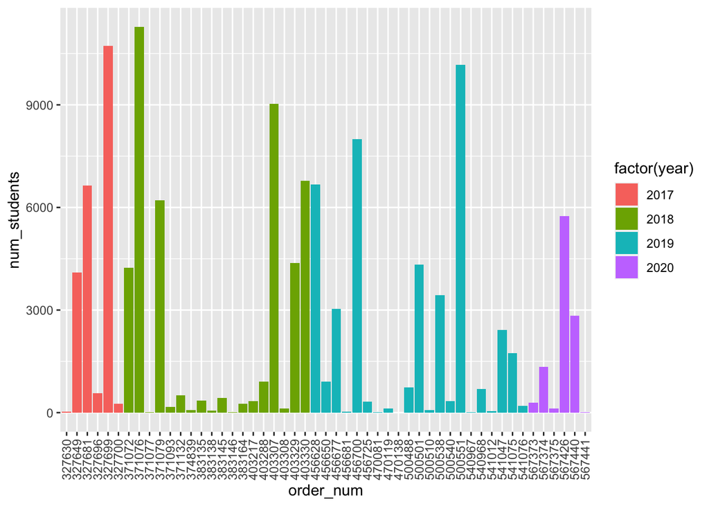

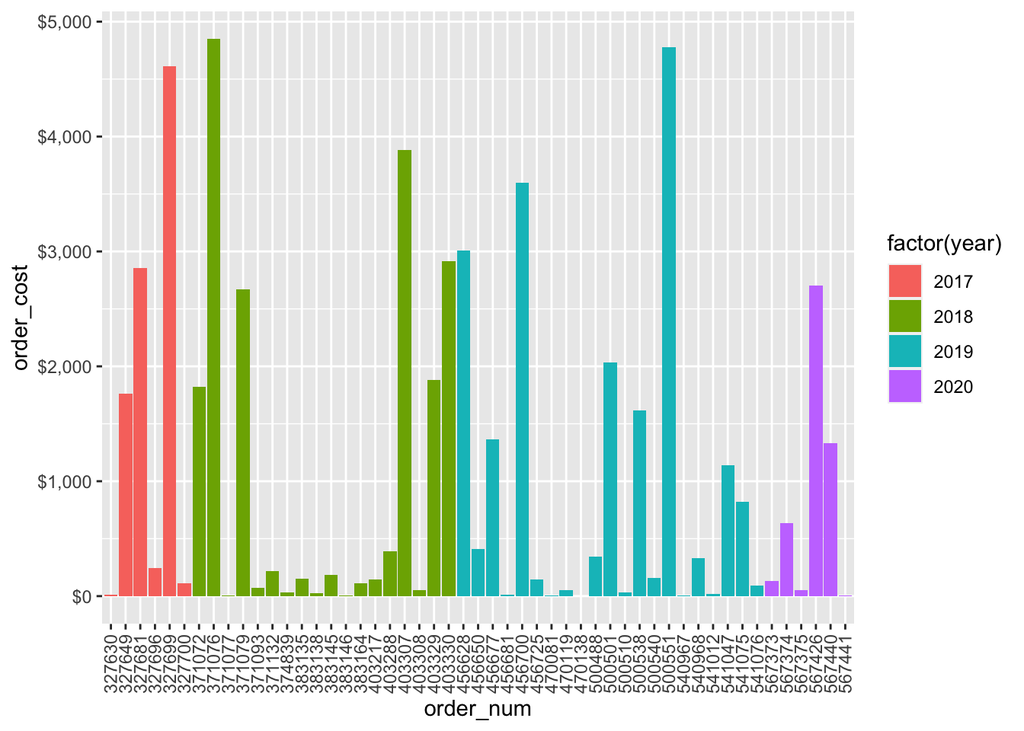

### 1.1.2 Filter Criteria

Generally, on each purchase date, they make **6 IL orders by race/ethnicity and test scores**:

- Race/ethnicity groups (A) + Test score range (low A)
- Race/ethnicity groups (A) + Test score range (med A)
- Race/ethnicity groups (A) + Test score range (high A)
- Race/ethnicity groups (B) + Test score range (low B)
- Race/ethnicity groups (B) + Test score range (med B)
- Race/ethnicity groups (B) + Test score range (high B)

**Group/filter definitions**:

- **Race/ethnicity groups (A)**
  - Asian (including Indian subcontinent and Philippines origin)|Other|I do not wish to respond to race|No, not of Hispanic, Latino, or Spanish origin|White (including Middle Eastern origin)|Native Hawaiian or Other Pacific Islander
    - Starting from **Fall 2019**, they removed “*Native Hawaiian or Other Pacific Islander*” from the **med** and **high** orders
  - **Test score range (low A)**: 1160 - 1270
  - **Test score range (med A)**: 1260/1280 - 1440
  - **Test score range (high A)**: 1450 - 1600
- **Race/ethnicity groups (B)**
  - Black or African American|American Indian or Alaska Native|Other Hispanic or Latino|Puerto Rican|Mexican|Hispanic or Latino (including Spanish origin)|Cuban
    - Starting from **Fall 2019**, they added “*Native Hawaiian or Other Pacific Islander*” to all orders (**low**, **med**, and **high**)
  - **Test score range (low B)**: 1020/1030 - 1190
  - **Test score range (med B)**: 1200 - 1350/1380
  - **Test score range (high B)**: 1360/1390 - 1600

**Common filters**:

[interactive chart not shown]

## 1.2 All years, out-of-state

### 1.2.1 Total number of orders, students, & spending

2018-2020 = 22 orders; 142,744 students; $641,18.54

- 2018 = 9 orders; 55879 students; $24,027.97
- 2019 = 11 orders; 61858 students; $28,337.28
- 2020 = 2 orders; 25007 students; $117,53.29

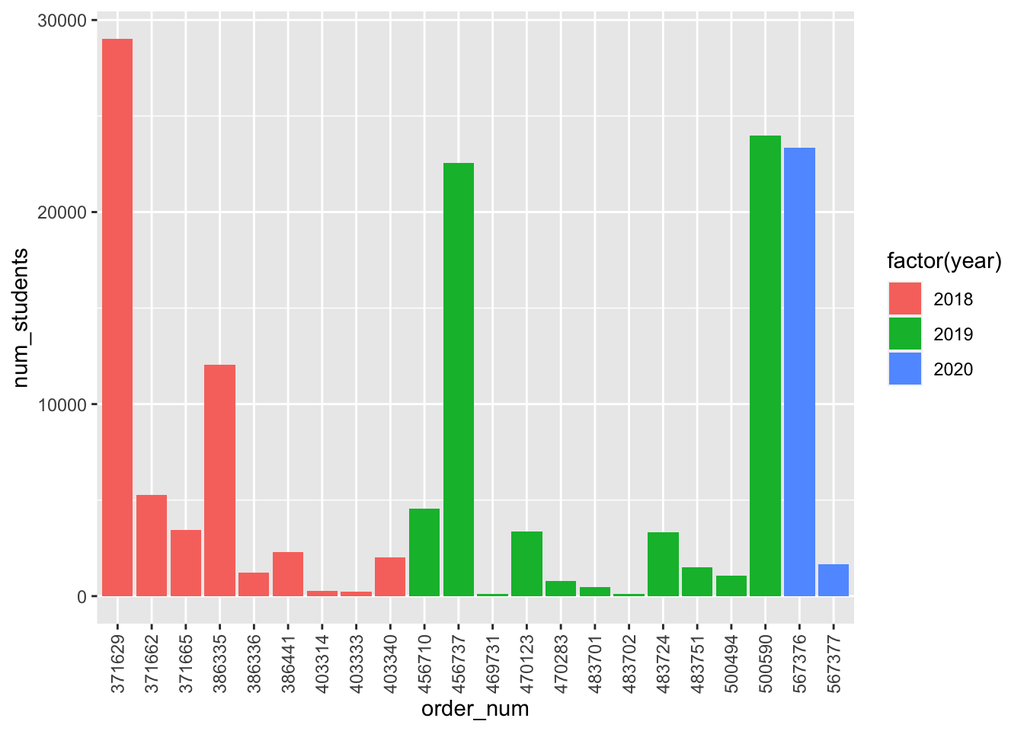

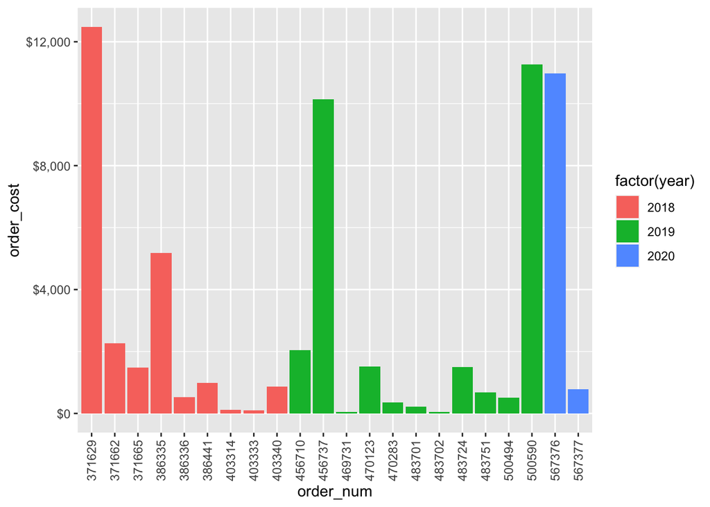

### 1.2.2 Filter Criteria

Based on geographic filters, we can categorize their orders into **3 broad categories**:

- Specific MSAs (3 orders)
- Non-engineering majors in specific MSAs + CA, CT, MO, and Armed Forces military districts (6 orders)
- Engineering majors in all 49 states except IL + DC (13 orders)

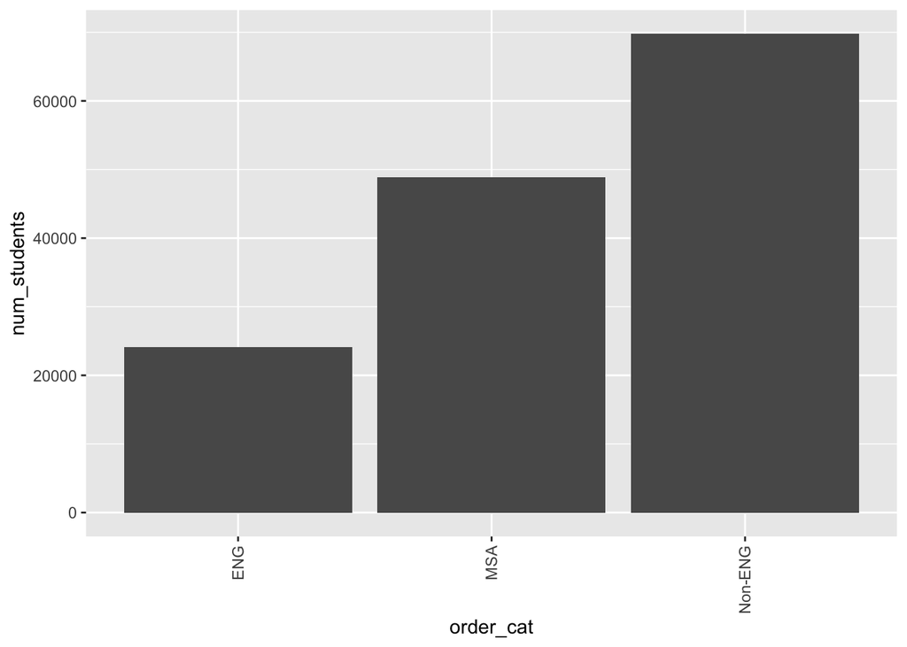

[figure not shown]

21 of the 22 out-of-state orders also use these [segment analysis](http://secure-media.collegeboard.org/mSSS/media/pdf/segment-analysis-service-overview.pdf) filters (total possible: *33 neighborhood clusters* and *29 high-school clusters*):

- **EN**:51, **HS**:65 | **EN**:51, **HS**:68 | **EN**:51, **HS**:70 | **EN**:51, **HS**:79
- **EN**:53, **HS**:65 | **EN**:53, **HS**:70 |
- **EN**:58, **HS**:64 | **EN**:58, **HS**:65 | **EN**:58, **HS**:70
- **EN**:60, **HS**:65 | **EN**:60, **HS**:68 | **EN**:60, **HS**:70 | **EN**:60, **HS**:79
- **EN**:61, **HS**:ALL
- **EN**:63, **HS**:65 | **EN**:63, **HS**:70
- **EN**:69, **HS**:68 | **EN**:69, **HS**:70 | **EN**:69, **HS**:75
- **EN**:70, **HS**:66 | **EN**:70, **HS**:68 | **EN**:70, **HS**:70 | **EN**:70, **HS**:79
- **EN**:73, **HS**:65 | **EN**:73, **HS**:70
- **EN**:78, **HS**:ALL

Sample **neighborhood clusters (EN)** characteristics from 2011:

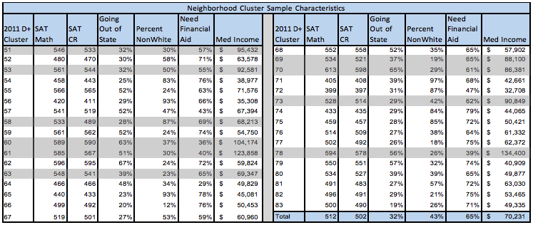

Sample **high school clusters (HS)** characteristics from 2011:

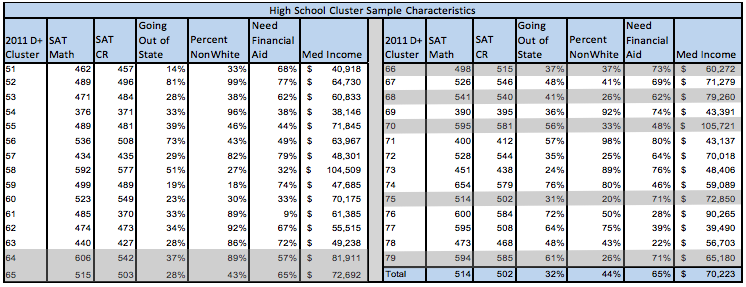

### 1.2.3 OOS Order Category: By MSA

- 2 orders in 2019
- 1 order in 2020

They made **2** “OOS Regional MSA” orders **1** “Regional Counselor MSAs” order.

- They used the segment analysis from above
- A+/B- high school GPA
- MSAs from states: CA, TX, GA, FL, NY, NJ

[interactive chart not shown]

### 1.2.4 OOS Order Category: Non-ENG orders

They made **5** “OOS Non-ENG” orders & **1** “OOS ENG and Non-ENG” order between **Feb 2018** & **Jun 2019** w/ the criteria:

- Specific MSAs + CA, CT, MO, and Armed Forces military districts
- Above segment analysis filter for the **5** Non-ENG only orders but not the 1 order that included ENG majors too
- A+ to B- high school GPA
- SAT score of 1230/1240 - 1450 or PSAT score of 1220/1230/1240 - 1450
  - The **1** ENG & Non-ENG order had criteria of SAT 1240 - 1450 or PSAT 1220 - 1450

[interactive chart not shown]

### 1.2.5 OOS Order Category: ENG orders

They made **6** “OOS ENG Male” orders & **7** “OOS ENG Female” orders between **Feb 2018** & **Apr 2020** w/ the criteria:

- All 49 states except IL + DC
- Above segment analysis filter
- A+ to B- high school GPA
- SAT/PSAT score filter which differs by gender

**General observations**:

- More purchases made for female students and w/ lower test score criteria, but resulting female engineering majors in list still less than total male students

### 1.2.6 OOS Order Category: International

```r
intl_orders
```

| univ_id | po_num | order_num | order_title | order_cost | num_runs | num_students | date_start | hs_grad_class | intl_region | sat_score_min | sat_score_max | sat_score_old_min | sat_score_old_max | psat_score_min | psat_score_max | psat_score_old_min | psat_score_old_max | gpa_high | gpa_low |
| --- | --- | --- | --- | --- | --- | --- | --- | --- | --- | --- | --- | --- | --- | --- | --- | --- | --- | --- | --- |
| 145637 | P1659111 | 483721 | 1150-1500 INTL Travel Countries Only | 395.55 | NA | 879 | 2019-06-27 | 2021\|2022 | AS-3 - Egypt\|AC-7 - Hong Kong\|AS-4 - India\|AC-8 - Indonesia\|AS-7 - Jordan\|AC-16 - Korea, South (ROK)\|AC-29 - Macao\|AC-10 - Malaysia\|AS-14 - Saudi Arabia\|AS-17 - United Arab Emirates\|AC-20 - … | 1200 | 1500 | 1130 | 1460 | 1150 | 1450 | 108 | 140 | A+ | B- |
| 145637 | P1558959 | 372044 | China Search - Feb 2018 | 985.99 | NA | 2293 | 2018-05-10 | 2019\|2021\|2020 | AC-5 - China | 1350 | 1600 | 1290 | 1600 | 1350 | 1520 | 129 | 149 | A+ | B- |
| 145637 | P1659111 | 470250 | International Non China Search March | 1384.20 | 4 | 3076 | 2019-03-27 | 2021\|2020\|2022 | EW-26 - Aaland Islands\|AS-19 - Afghanistan\|EC-13 - Albania\|CA01 - Alberta\|CA01 - Alberta\|AF-28 - Algeria\|EW-27 - Andorra\|AF-29 - Angola\|CR-12 - Anguilla\|CR-13 - Antigua and Barbuda\|SA-2 - Ar… | 1240 | 1450 | 1170 | 1400 | 1240 | 1450 | 117 | 140 | A+ | B- |
| 145637 | P1558959 | 371669 | Intl Broad Search - Feb 2018 | 4534.78 | NA | 10546 | 2018-05-10 | 2019\|2021\|2020 | AC-7 - Hong Kong\|AS-4 - India\|AC-8 - Indonesia\|AC-9 - Japan\|AC-16 - Korea, South (ROK)\|AF-17 - Nigeria\|AS-12 - Pakistan\|AS-13 - Qatar\|AS-14 - Saudi Arabia\|AC-15 - Singapore\|AC-17 - Taiwan\|A… | 1240 | 1600 | 1170 | 1600 | 1240 | 1520 | 117 | 149 | A+ | B- |

They made **4** international orders between **May 2018** & **June 2019** with the following search criteria:

- All filter for A+/B- high school GPA
- SAT/PSAT scores vary by country.

```r
intl_orders %>% dplyr::select(order_title, order_num, num_students, sat_score_min, sat_score_max, psat_score_min, psat_score_max)
```

| order_title | order_num | num_students | sat_score_min | sat_score_max | psat_score_min | psat_score_max |
| --- | --- | --- | --- | --- | --- | --- |
| 1150-1500 INTL Travel Countries Only | 483721 | 879 | 1200 | 1500 | 1150 | 1450 |
| China Search - Feb 2018 | 372044 | 2293 | 1350 | 1600 | 1350 | 1520 |
| International Non China Search March | 470250 | 3076 | 1240 | 1450 | 1240 | 1450 |
| Intl Broad Search - Feb 2018 | 371669 | 10546 | 1240 | 1600 | 1240 | 1520 |

# 2 RQ: What are the characteristics of schools/communities included vs. not included in purchased lists

## 2.1 Communities: Out-of-State, zip codes purchased from vs. not purchased from

All “non-purchased” zipcodes included below are only those in states where at least one student was purchased within at least one zipcode

- Binary version of purchased_zip is problematic because of variation in number of students purchased by zip

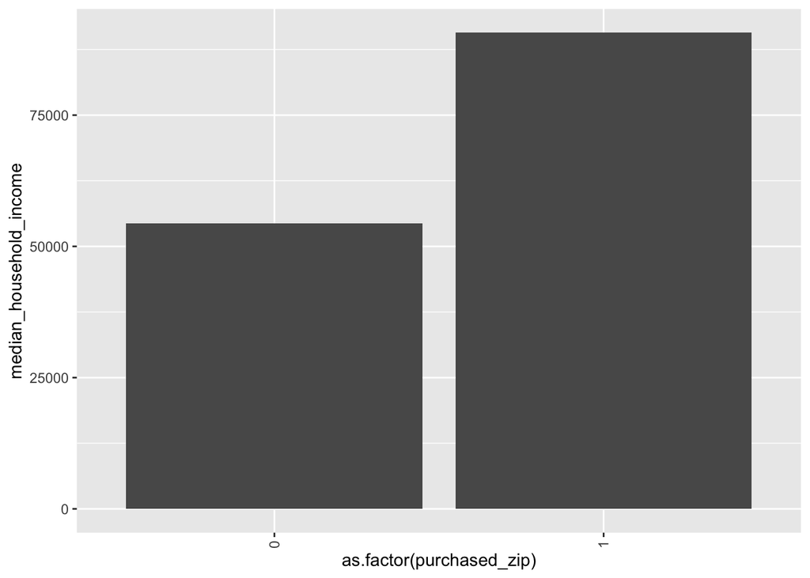

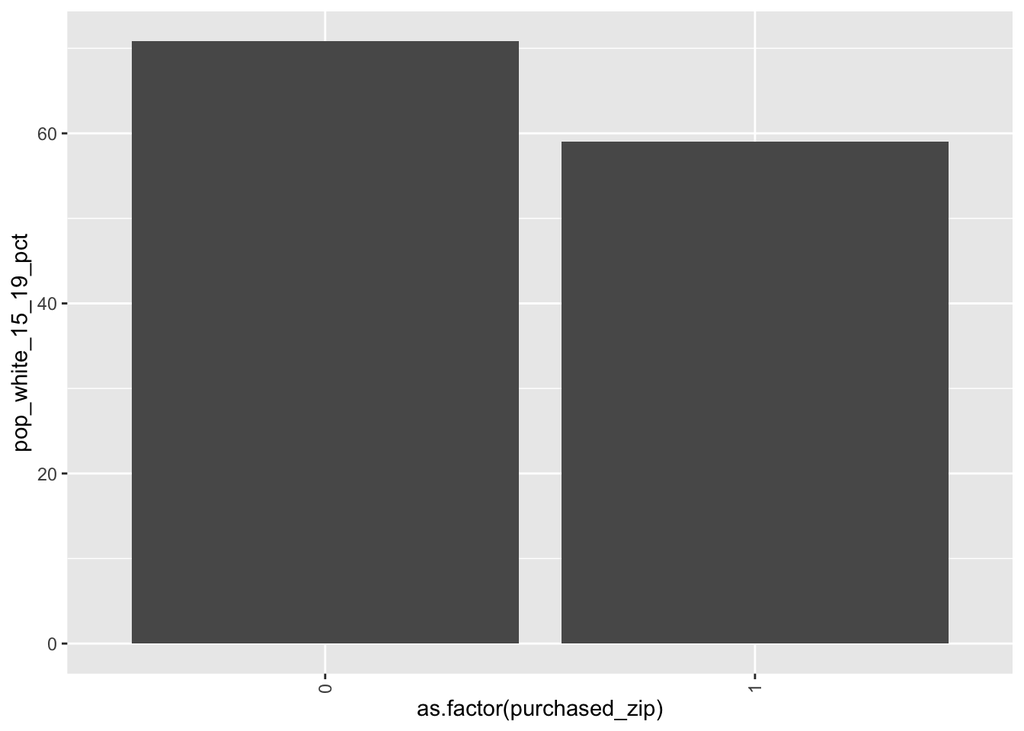

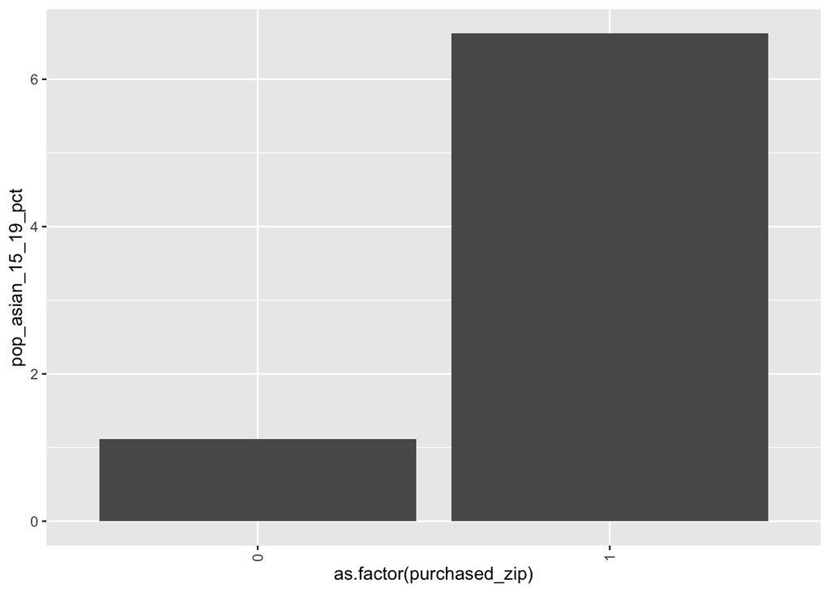

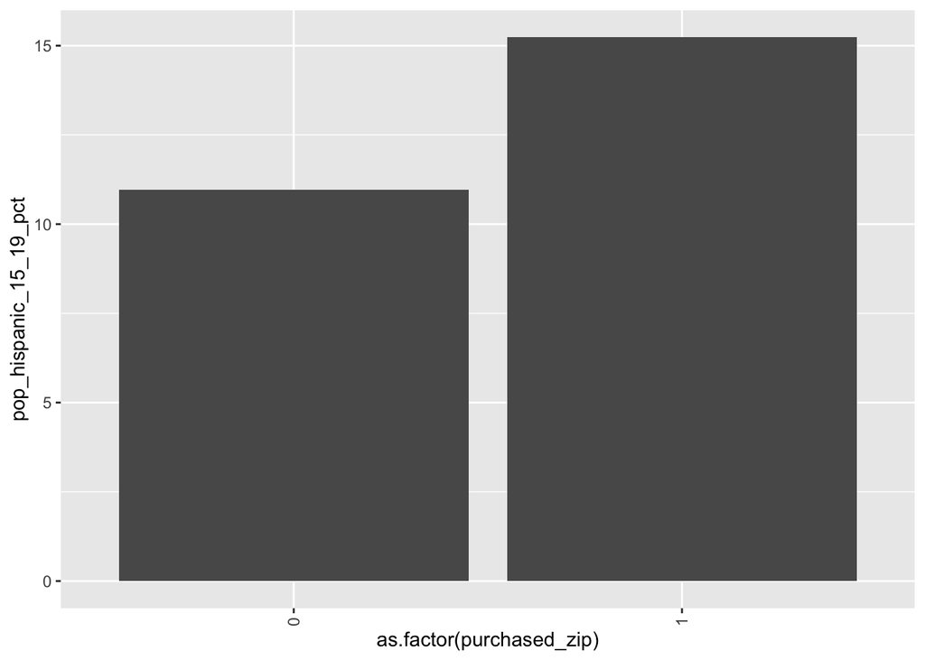

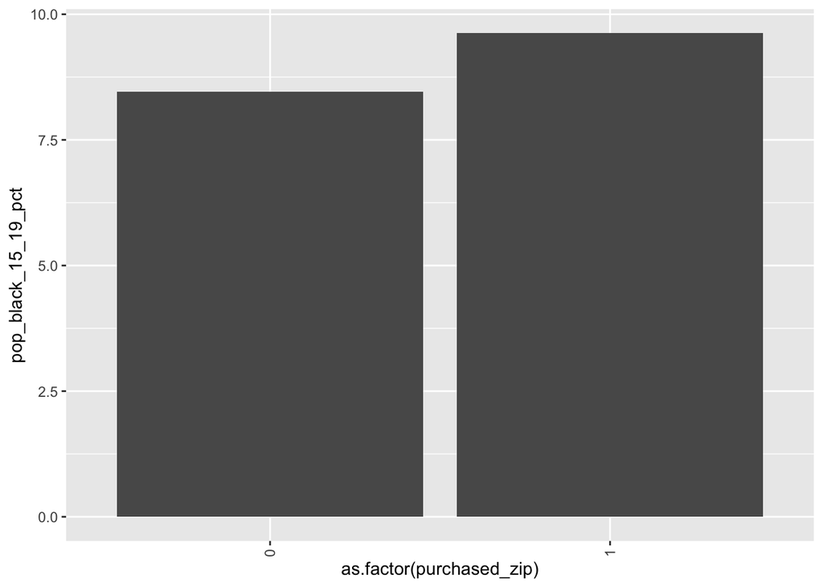

## 2.2 Out-of-State, zip codes charactertistics based on # of names purchased

| purchased_num_mean | purchased_num_sd | purchased_num_med | purchased_num_min | purchased_num_max |
| --- | --- | --- | --- | --- |
| 40.50731 | 78.62888 | 10 | 1 | 1140 |

| state_code | purchased_num_mean | purchased_num_sd | purchased_num_med | purchased_num_min | purchased_num_max |
| --- | --- | --- | --- | --- | --- |
| AK | 2.800000 | 1.9235384 | 2.0 | 1 | 6 |
| AL | 3.906250 | 3.4300322 | 3.0 | 1 | 16 |
| AR | 2.000000 | 1.6172151 | 1.0 | 1 | 6 |
| AZ | 23.547945 | 34.6097454 | 8.0 | 1 | 162 |
| CA | 67.474172 | 114.0842344 | 26.0 | 1 | 1140 |
| CO | 19.274336 | 29.1496287 | 6.0 | 1 | 187 |
| CT | 27.000000 | 39.9764298 | 9.0 | 1 | 217 |
| DC | 30.500000 | 34.3325243 | 12.5 | 2 | 101 |
| DE | 47.294118 | 47.1006432 | 32.0 | 1 | 151 |
| FL | 37.914110 | 59.2245166 | 13.0 | 1 | 371 |

[output cut: 41 more lines]

| purchased_num_cat | n |
| --- | --- |
| zero | 26200 |
| 1-10 | 2861 |
| 11-40 | 1233 |
| 41-100 | 792 |
| 101-500 | 630 |
| 500+ | 21 |

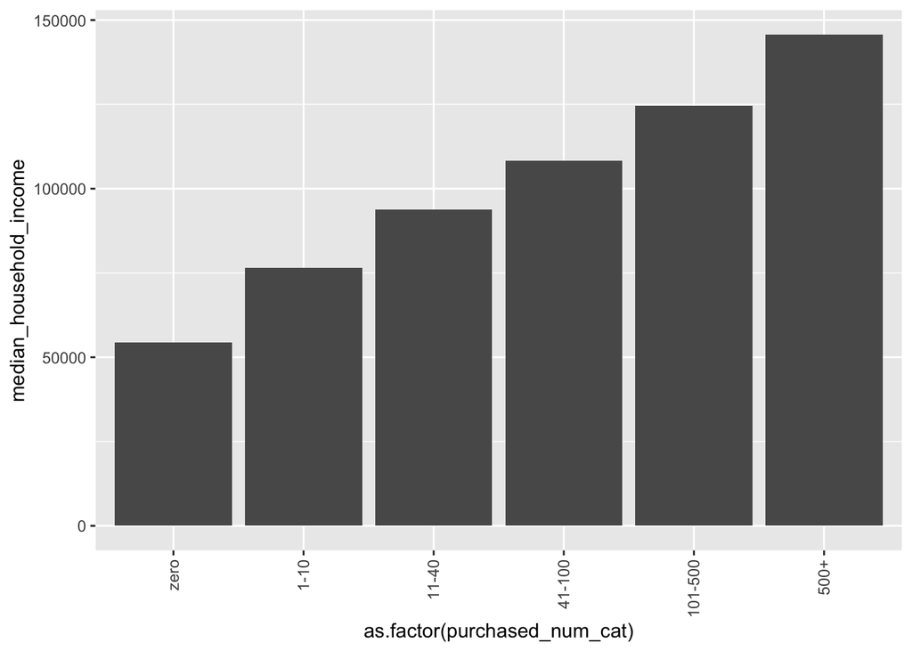

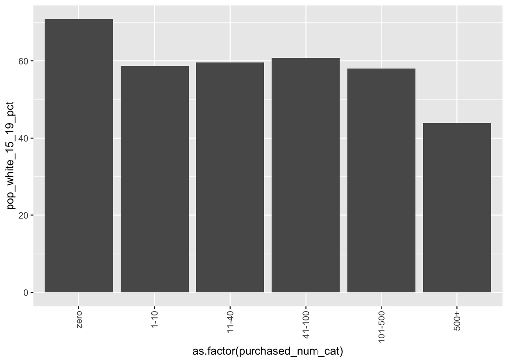

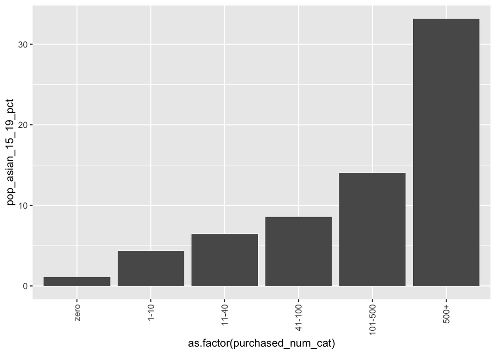

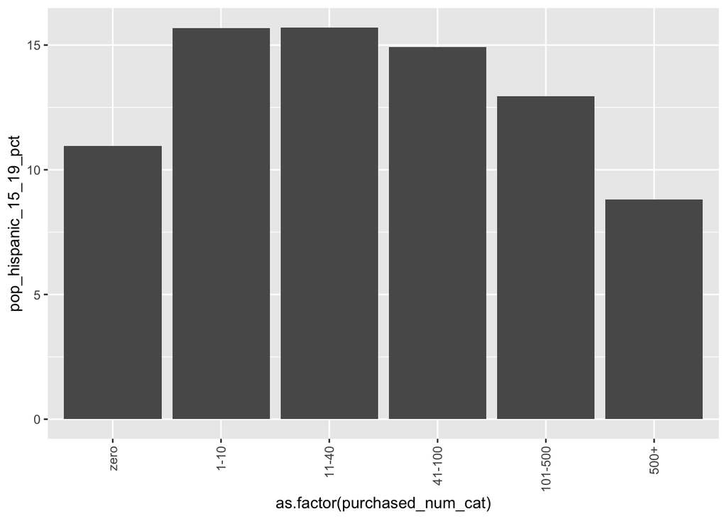

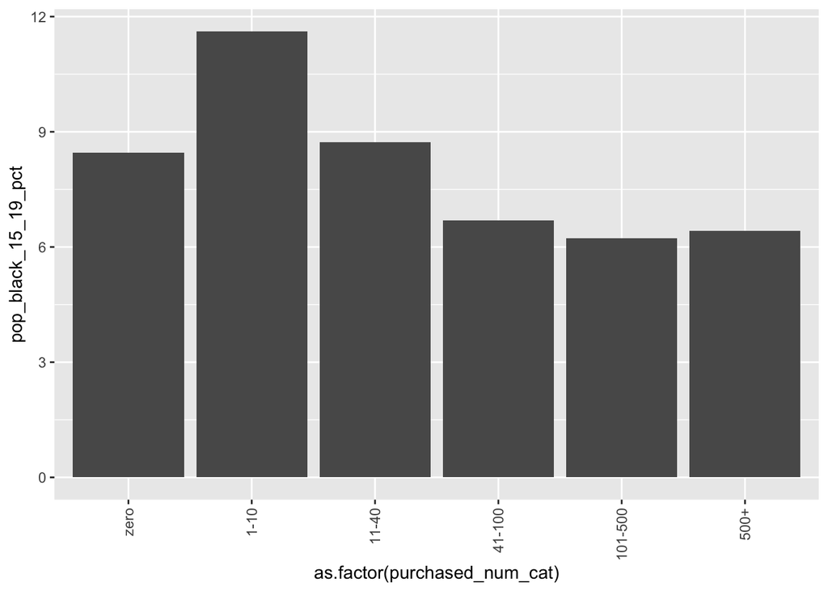

## 2.3 Schools: Descriptives across U.S. (filtered by purchased states)

## 2.4 Schools: Zoom into Metros (filtered by purchased states)

# 3 Overall Findings/Themes

## 3 Out-of-State